# 2021-03-17_Workbook-4

Emma

16/03/2021

Q1. Warmup Using the nz dataset, make all the hours variables into integers

```r
#Q1. Changing variables into integers

nz1 <- nz %>%
  dplyr::mutate(
           Hours.Exercise = as.integer(Hours.Exercise),
           HLTH.SleepHours = as.integer(HLTH.SleepHours),
           Hours.Internet = as.integer(Hours.Internet),
           Hours.Work = as.integer(Hours.Work),
           Hours.News = as.integer(Hours.News),
           HoursCharity = as.integer(HoursCharity))
str(nz1)
```

```
## tibble [4,126 x 63] (S3: tbl_df/tbl/data.frame)
##  $ Id                         : num [1:4126] 1 1 2 2 3 3 4 4 5 5 ...
##  $ Wave                       : Factor w/ 2 levels "2018","2019": 2 1 2 1 2 1 2 1 2 1 ...
##  $ years                      : num [1:4126] 10.43 9.47 10.61 9.9 10.17 ...
##  $ Age                        : num [1:4126] 47 46 47 46 53 52 60 59 84 84 ...
##  $ Male                       : Factor w/ 2 levels "Male","Not_Male": 1 1 1 1 1 1 2 2 2 2 ...
##  $ Gender                     : num [1:4126] 1 1 1 1 1 1 0 0 0 0 ...
##  $ Edu                        : num [1:4126] 3 3 7 7 4 4 8 7 7 7 ...
##  $ Partner                    : num [1:4126] 1 1 1 1 0 0 1 NA 0 0 ...
##  $ BornNZ                     : num [1:4126] 1 1 1 1 1 1 1 1 1 1 ...
##  $ Employed                   : num [1:4126] 1 0 1 1 1 1 1 NA 0 0 ...
##  $ BigDoms                    : Factor w/ 5 levels "Buddhist","Christian",..: 4 4 4 4 4 4 5 5 2 2 ...
##  $ TSCORE                     : num [1:4126] 3869 3520 3936 3677 3774 ...
##  $ GenCohort                  : Factor w/ 5 levels "Gen Boombers: born >= 1946 & b.< 1961",..: 3 3 3 3 3 3 1 1 2 2 ...
##  $ Religion.Church            : num [1:4126] 0 0 0 0 0 0 2 NA 0 0 ...
```

[output cut: 49 more lines]

```r
#use str to check that they have been changed to integers.
```

Q2a. Scale, center, transform Create a new indicator that standardises the Pol.Orient variable, create a new indicator that centers the Pol.Orient variable, create a new indicator that centres the Age variable in decade-long units. Do this in a single piped workflow.

Print the head of the data frame so that we can see your work

```r
NZ_2 <- nz%>%
  select(Pol.Orient, Age)%>%
   mutate(Pol.Orient_S = scale(Pol.Orient, scale = TRUE, center  = TRUE))%>%
  #new indicator and centered variable
         mutate(Age1 = scale(Age, scale = FALSE, center = TRUE)/10)
#new indicator that centers age in decade long units
head(NZ_2)
```

```
## # A tibble: 6 x 4
##   Pol.Orient   Age Pol.Orient_S[,1] Age1[,1]
##        <dbl> <dbl>            <dbl>    <dbl>
## 1          3    47           -0.420   -0.357
## 2          3    46           -0.420   -0.457
## 3          5    47            1.02    -0.357
## 4          3    46           -0.420   -0.457
## 5          4    53            0.301    0.243
## 6          4    52            0.301    0.143
```

```r
#/10 divide by 10 to create decade.
```

Q2b Data wrangle Select Hour.Exercise and filter Wave 2019.

```r
nz_4 <- nz%>%
  select(Hours.Exercise, Wave)%>%
  mutate(Hours.Exercise_s = scale(Hours.Exercise, scale = TRUE, center = TRUE))%>%
      filter(Wave == "2019")

head(nz_4)
```

```
## # A tibble: 6 x 3
##   Hours.Exercise Wave  Hours.Exercise_s[,1]
##            <dbl> <fct>                <dbl>
## 1             14 2019                1.03
## 2              7 2019                0.161
## 3              5 2019               -0.0874
## 4              1 2019               -0.585
## 5              1 2019               -0.585
## 6              0 2019               -0.709
```

Q3. Working with dates What are the maximum number of responses for a single day in 2018 and the maximum number of responses for a single day in 2019?

```r
# the below code prints a tible that lists max # responses in descending order.
datrep5 <- nz %>%
  count(day = floor_date(date, "day"))%>%
  dplyr::mutate(Year = factor(ifelse(
    day < "2018-01-01",
    2017,
    ifelse(day < "2019-01-01", 2018,
           ifelse(day < "2020-01-01", 2019, 2020))
  ))) %>%
  arrange(day)

datrep5%>%
  arrange(desc(n))
```

```
## # A tibble: 607 x 3
##    day            n Year
##    <date>     <int> <fct>
##  1 2018-06-21   112 2018
##  2 2018-06-22    93 2018
##  3 2018-06-24    80 2018
##  4 2018-06-20    67 2018
##  5 2018-06-23    59 2018
##  6 2018-06-26    58 2018
##  7 2019-12-03    54 2019
##  8 2018-06-25    52 2018
##  9 2019-10-04    47 2019
## 10 2019-12-02    46 2019
## # ... with 597 more rows
```

```r
# looking at the above tible the answers are:
# max response for 2018 is 2018-06-21 (n=112)
# max responses for 2019 is 2019-12-03 (n=54)
```

Q4 Caculating dates and creating summaries How many days are there between the date with the highest number of responses and the date with the second highest number of responses?

Information is pulled from the above summary.

The date with the highest number of responses = 2018-06-21 (n=112) The date with second highest number of responses = 2018-06-22 (n=93)

The days in between those two dates is one.

Bonus:

The difference between the number of responses is =

```r
112-93
```

```
## [1] 19
```

Q5. Working with date intervals Suppose you were born on Dec 25, 1995 at 5.02:22 am Calculate your age in months on March 20,2021, at 1:22:04pm.

```r
# time between two dates in months

interval(ymd_hms("1995-12-25 05:02:22"), ymd_hms("2021-03-20 13:22:04")) %/% months(1)
```

```
## [1] 302
```

Q6 Create an ordered factor from numeric data The Religion.Church variable contains responses to the question: “How many times each month do you attend church or religious service?”

Create factor with the following three levels:

People who attend church 0 times per month, People who attend church 1-3 times per month, People who attend church 4 or more times per month. Make sure to re-level the factor so that the ordinal ranking moves from lowest to highest.

```r
# cut function

nz_5 <- nz %>%
  dplyr::mutate(Religion.Church = cut(Religion.Church,
                breaks = c(-Inf, 0, 4, Inf),
                labels = c("No Attendance", "Moderate Attendance", "High Attendance"),
                right = TRUE
                ))
table(nz_5$Religion.Church, useNA = "ifany")
```

```
##
##       No Attendance Moderate Attendance     High Attendance                <NA>
##                3366                 493                 158                 109
```

Q7.a Make a summary table Using methods described in Lecture 4, create a table for average hours of sleep by month in the nz dataset

Q7.b Make a summary graph Graph the average hours of sleep by month including 95% confidence intervals

Briefly explain why some intervals are wider than others.

```r
# arranging the date into month format

nz10 <- nz %>%
  select(date, HLTH.SleepHours) %>%
  mutate(Months = month(date, label = TRUE)) %>%
  group_by(Months) %>%
  arrange(Months)


# the table
library(kableExtra)
nz10 %>%
  select(HLTH.SleepHours, Months) %>%
  filter(!is.na(HLTH.SleepHours))%>%
  group_by(Months) %>%
  summarise(av_sleep = mean(HLTH.SleepHours, na.rm = T))%>%
  pivot_wider(names_from = Months, values_from = av_sleep) %>%
  kbl(caption = "Ave Hours Sleep by Month") %>%
  kable_classic_2(c("striped", "hover"), full_width = TRUE)%>%
  collapse_rows()
```

Ave Hours Sleep by Month

| Jan | Feb | Mar | Apr | May | Jun | Jul | Aug | Sep | Oct | Nov | Dec |
| --- | --- | --- | --- | --- | --- | --- | --- | --- | --- | --- | --- |
| 6.810909 | 6.666667 | 6.792891 | 7.279487 | 7.064935 | 6.927352 | 6.957453 | 6.976087 | 6.666667 | 6.912844 | 6.940741 | 6.872973 |

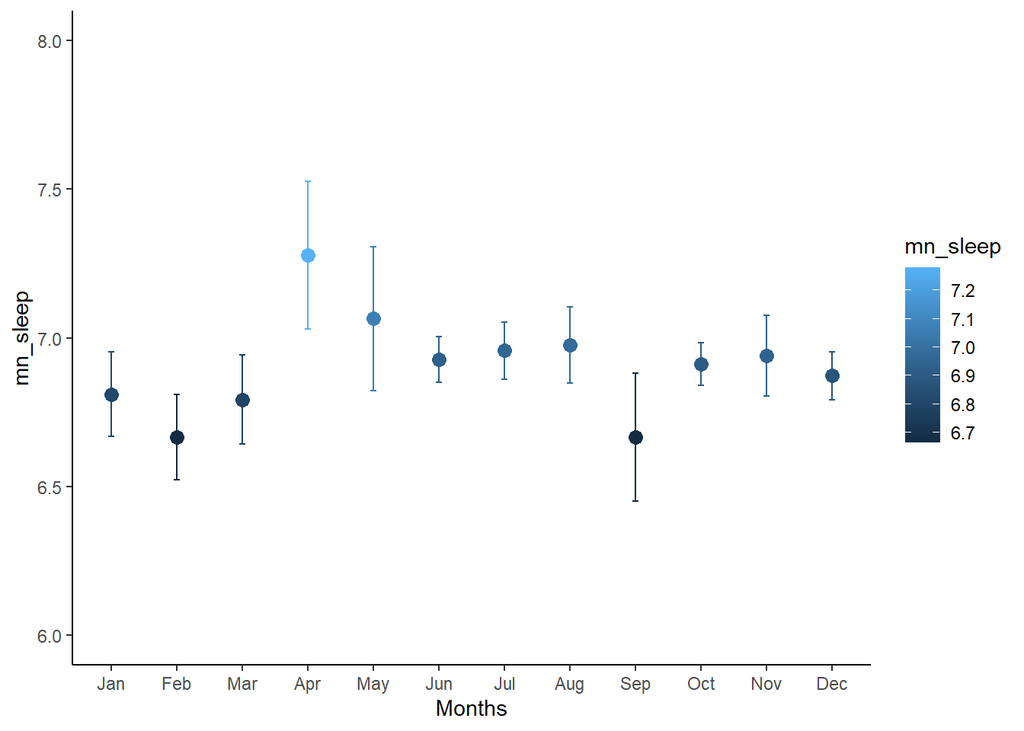

```r
# the summary graph

nz10 %>%
  select(date, HLTH.SleepHours) %>%
  mutate(Months = month(date, label = TRUE)) %>%
  group_by(Months) %>%
  summarise(
    mn_sleep =  mean(HLTH.SleepHours, na.rm = TRUE),
    sd_sleep =  sd(HLTH.SleepHours, na.rm = TRUE),
    n_sleep = n()
  ) %>%
  mutate(
    se_sleep = sd_sleep / sqrt(n_sleep),
    lw_ci = mn_sleep - qt(1 - (0.05 / 2), n_sleep - 1) * se_sleep,
    up_ci = mn_sleep + qt(1 - (0.05 / 2), n_sleep - 1) * se_sleep
  ) %>%
  ggplot(., aes(x = Months, y = mn_sleep, colour = mn_sleep)) +
  geom_errorbar(aes(ymin = lw_ci, ymax = up_ci), width = .1) +
  geom_point(size = 3) +
  scale_y_continuous(limits = c(6,8)) +
  theme_classic() + scale_fill_viridis_d()
```

Some intervals are wider than others in the above graph because there is more variation in the data for those months.

Q8. Correlation graph Created a correlation graph for the items in the Kessler 6 scale

These are FeelHopeless,FeelDepressed,FeelRestless,EverythingIsEffort,FeelWorthless,FeelNervous

```r
# transform data

corKes6 <- nz %>%
  select(FeelHopeless,
         FeelDepressed,
         FeelRestless,
         EverythingIsEffort,
         FeelWorthless,
         FeelNervous,
         KESSLER6sum
         ) %>%
  mutate_all(., as.integer) %>%
  mutate(KESSLER6sum = as.factor(KESSLER6sum),
         FeelNervous = log(FeelNervous + 1))

# correlation plot one

library(correlation)
p1 <- corKes6 %>%
  correlation(partial = FALSE, multilevel = TRUE ) %>%
  plot()

# viewing the first plot

corKes6 %>%
  correlation(partial = FALSE, multilevel = TRUE ) %>%
  summary()
```

```
## Parameter          | FeelNervous | FeelWorthless | EverythingIsEffort | FeelRestless | FeelDepressed
## ----------------------------------------------------------------------------------------------------
## FeelHopeless       |    -0.29*** |          0.02 |           -0.22*** |     -0.33*** |       0.06***
## FeelDepressed      |    -0.26*** |     -6.63e-03 |           -0.17*** |     -0.30*** |
## FeelRestless       |    -0.14*** |      -0.29*** |           -0.22*** |              |
## EverythingIsEffort |    -0.30*** |      -0.21*** |                    |              |
## FeelWorthless      |    -0.21*** |               |                    |              |
```

```r
# correlation plot two

p2 <- corKes6 %>%
  select(-KESSLER6sum)%>%
  correlation(partial = FALSE, multilevel = FALSE ) %>%
  plot()


corKes6 %>%
  select(-KESSLER6sum)%>%
  correlation(partial = FALSE, multilevel = FALSE ) %>%
  summary()
```

```
## # Correlation Matrix (pearson-method)
##
## Parameter          | FeelNervous | FeelWorthless | EverythingIsEffort | FeelRestless | FeelDepressed
## ----------------------------------------------------------------------------------------------------
## FeelHopeless       |     0.43*** |       0.65*** |            0.52*** |      0.43*** |       0.66***
## FeelDepressed      |     0.38*** |       0.67*** |            0.49*** |      0.38*** |
## FeelRestless       |     0.46*** |       0.39*** |            0.46*** |              |
## EverythingIsEffort |     0.42*** |       0.47*** |                    |              |
## FeelWorthless      |     0.40*** |               |                    |              |
##
## p-value adjustment method: Holm (1979)
```

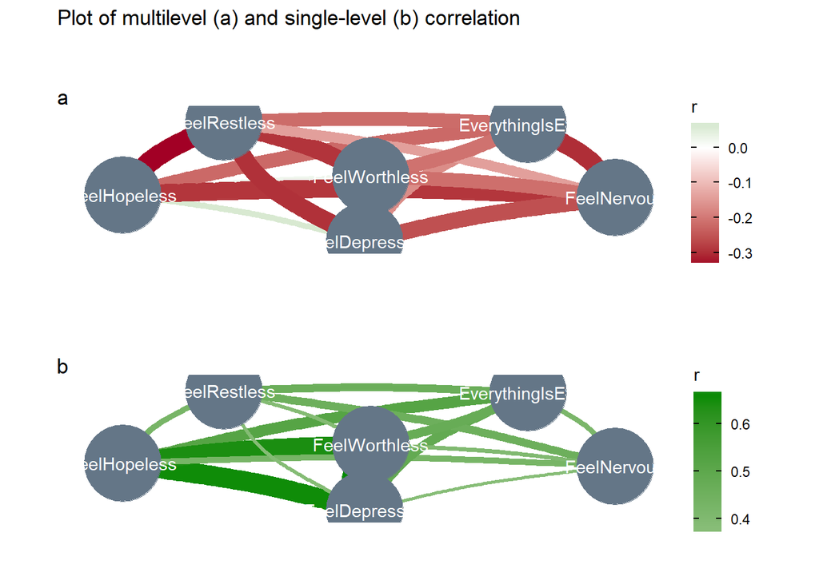

```r
# creating the correlation graph

library(patchwork)
# create a two panel plot
p1 / p2 +
  plot_annotation(title = "Plot of multilevel (a) and single-level (b) correlation", tag_levels = 'a')
```

```r
# tried to use this code: plot_layout(widths = c(2, 5), heights = c(5, 2)) to change the size of the correlations, but it would only make one more squished and the other a little fatter!
```

What do you find most interesting about this plot?

The stronger correlations in Plot b are between feeling hopeless, worthless and depressed. These are all highly negative states, but I wonder why there aren’t equally as strong correlations between them and EverythingIsEffort.

Q9 Blank Papaja report is attached on blackboard.

Q10 Patchwork Use the patchwork library to create a figure with two plots on top of each other.

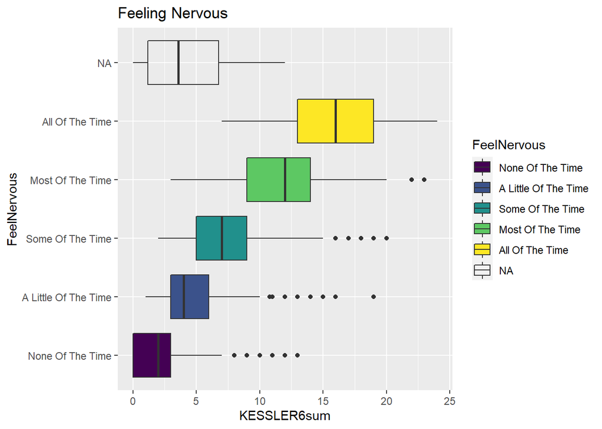

```r
# two plots that are on top of each other using patchwork

p3 <- ggplot(data = nz, aes(x = KESSLER6sum, y = FeelNervous, fill = FeelNervous)) +
  geom_boxplot(notch=FALSE) + scale_fill_viridis_d() +
  ggtitle('Feeling Nervous')


p4 <- ggplot(data = nz, aes(x = KESSLER6sum, y = FeelHopeless, fill = FeelHopeless)) +
  geom_boxplot(notch=FALSE) + scale_fill_viridis_d() +
  ggtitle('Feeling Hopeless')

p4_dims <- get_dim(p4)
p3_aligned <- set_dim(p3, p4_dims)
plot(p3_aligned)
```

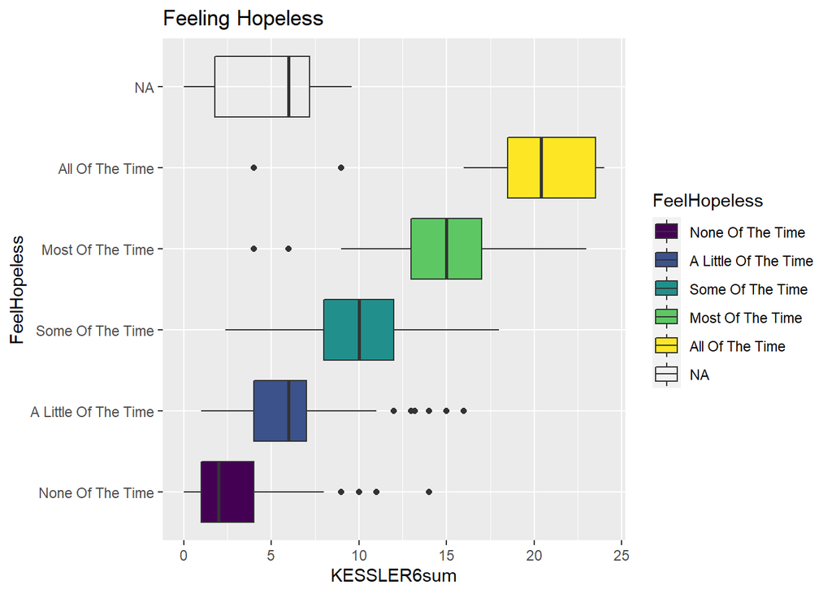

```r
plot(p4)
```

```r
# code should make two plots that flash one on top of the other. Unsure if this is accurate as haven't been able to knit to PDF where it would show!
```